# Catapult Project

MeowmyofSix

2023-11-15

# 1 Statement of Purpose

This project is designed to use new skills learned over the course of the semester to design and implement an experiment as well as analyze the resulting data. The experiment used for this project involved using a toy catapult to measure the distance traveled of a ping pong ball shot from the catapult. This data was then to be used to create a model to help the user to determine the settings on the catapult that would maximize the distance the ball would travel as well as accurately and precisely fire the ping pong ball to a certain distance.

# 2 Description of Experiment and List of Variables

Over the course of three weeks in November 2023 and December 2023, students in Dr. Professor’s Experimental Design class worked individually to collect data using toy catapults provided by Dr. Professor. The catapults provided were the XPULT Experimental Catapult, which is a product of Peloton Systems LLC. According to the XPULT website, “The catapult was originally developed for us in teaching design of experiments and process improvement in the university classroom.”

Included in the XPULT Experimental Catapult kit were two balls (a perforated ping pong ball and a smooth ping pong ball), rubber bands (newly purchased units have three rubber bands that are 3 inches by 1/8 inch), a plastic clamp, and the catapult device. The catapult device consists of two metal bars (the firing arm and a stabilization arm) connected to a wheel with holes and markings that designate launch and pull back angles for firing the catapult. A metal locking pin is used to lock in the launch angle and the rubber bands are used to facilitate the stabilization of the pull-back angle. On the far end of the firing arm was a small, flexible plastic ball cup to rest the object to be fired. **Figures 1** and **2** (next page) are images from the XPULT Experimental Catapult website that depict what is included in the kit and the general setup of the catapult.

[figure not shown]

**Figure 1. Photo from Peloton Systems LLC of XPULT Experimental Catapult Kit Contents.**

[figure not shown]

**Figure 2. Photo from Peloton Systems LLC of XPULT Experimental Catapult in the deployed position.**

A consensus was reached among the class to only use the smooth ping pong ball and to use two rubber bands for stabilizing the catapult arm. The main factors that were adjusted on the catapult were the launch angle and the pull back angle. The launch angle was adjusted to six different levels: 0, 15, 30, 45, 60, and 75 degrees. The pull back angle was also adjusted to six different levels: 30, 45, 60, 75, 90, and 105 degrees.

A standard 25 ft tape measure was used to measure the distance the ping pong ball flew from the ball cup when the catapult arm was released from its pull back angle. The tape measure was kept in place on the floor using duct tape. The zero inch mark on the tape measure was roughly aligned with the fulcrum of the catapult. The catapult was attached to a table that was roughly 32” in height using the plastic clamp (**Figure 3** shows the table used for the experiment). As stated above, two rubber bands were used to stabilize the pull back angle on the catapult setup. A total of 180 observations were made by each student (which equates to 5 observations per each of the 36 factor settings).

[figure not shown]

**Figure 3. Photo of the table used to stabilize the catapult.**

For the particular data set used in this write up, much of the data (115 out of 180 observations) was collected on November 15, 2023 in PE 137. Fellow Student was the person who measured the distance the ball traveled from the catapult and MeowmyofSix adjusted the settings on the catapult, fired the catapult, and recorded the distance traveled in a Microsoft Excel workbook spreadsheet. The rest of the data was collected on November 21, 2023 in PE 135. Again, Fellow Student measured the distance the ball traveled and MeowmyofSix adjusted and fired the catapult and recorded the distance traveled. The same table shown in **Figure 3** was used to stabilize the catapult in both rooms. A different tape measure was used each day, but each tape measure was a standard 25-foot retractable tape measure.

**Table 1** summarizes the independent and dependent variables for the experiment.

Table 1. Summary of Variables

[output not shown]

# 3 Data Setup and Descriptive Summary

The statistical computing programming language, R, and the integrated development environment, RStudio, were used for processing the data and creating and analyzing the resulting model.

**Figure 4**, **Figure 5**, and **Figure 6** are a boxplot, histogram, and QQ plot (respectively) that show that the measured distances appear to be normally distributed. **Table 2** shows the minimum distance traveled was 26 inches, the median and mean were close at 90.50 inches and 90.99 inches, respectively, and the maximum distance measured was 159 inches.

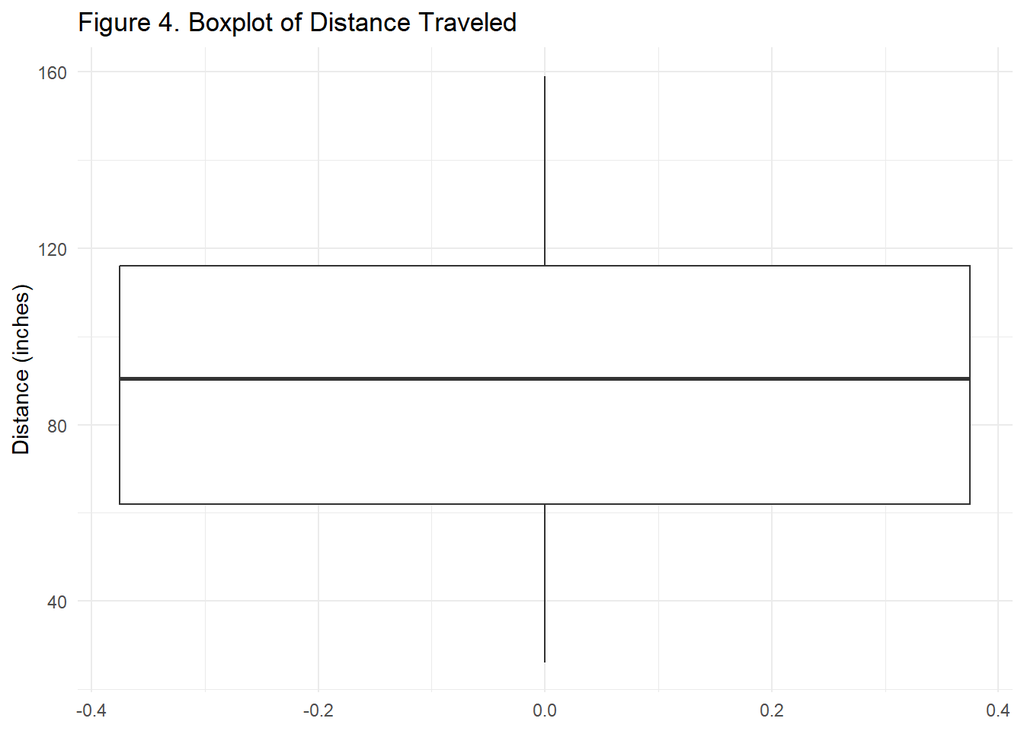

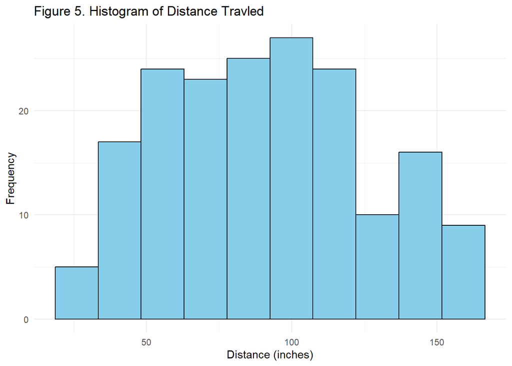

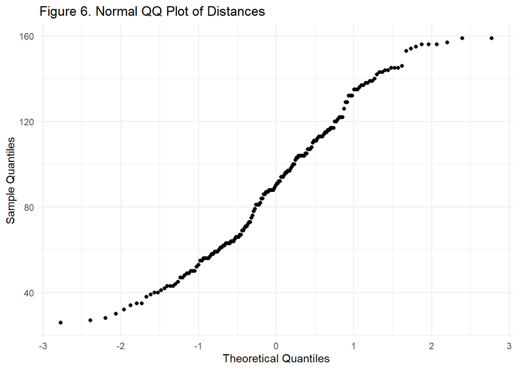

Table 2. Descriptive Summary of Distances

| Min | Q1 | Median | Mean | Q3 | Max |
| --- | --- | --- | --- | --- | --- |
| 26 | 62 | 90.5 | 90.99444 | 116 | 159 |

**Figure 7** and **Table 3** depict and summarize the distances traveled by the launch angle used. It appears that as the launch angle increases, the distance traveled decreases. The launch angle of 0 had the widest range of distance, with launch angles 60 and 75 having more narrow ranges of distance.

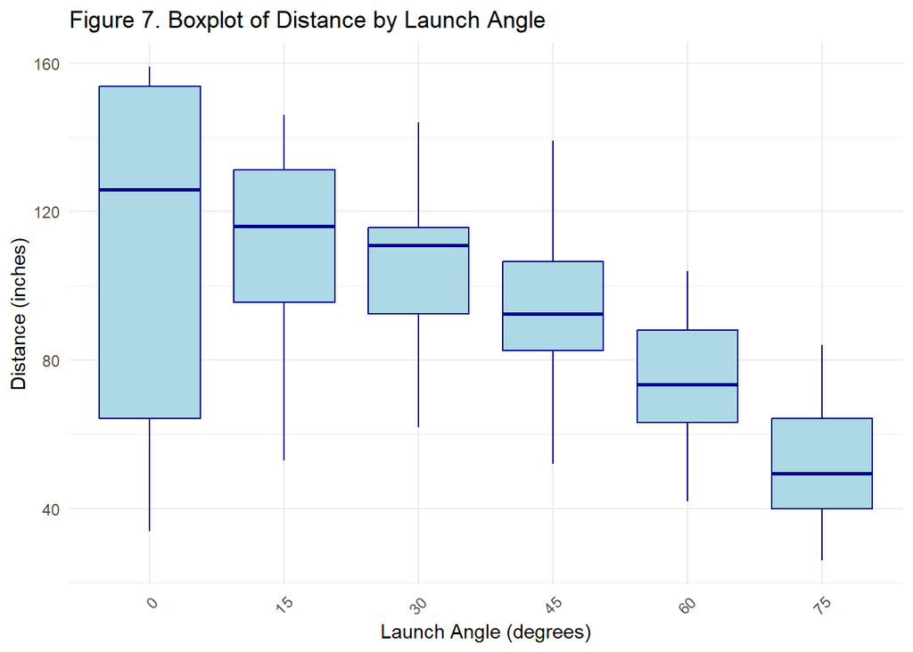

Table 3. Descriptive Summary of Distance by Launch Angle

| LaunchAngleFactor | Min | Q1 | Median | Mean | Q3 | Max |
| --- | --- | --- | --- | --- | --- | --- |
| 0 | 34 | 64.25 | 126.0 | 110.96667 | 153.75 | 159 |
| 15 | 53 | 95.50 | 116.0 | 108.46667 | 131.25 | 146 |
| 30 | 62 | 92.50 | 111.0 | 105.30000 | 115.75 | 144 |
| 45 | 52 | 82.50 | 92.5 | 95.13333 | 106.50 | 139 |
| 60 | 42 | 63.25 | 73.5 | 74.73333 | 88.00 | 104 |
| 75 | 26 | 40.00 | 49.5 | 51.36667 | 64.25 | 84 |

**Figure 8** and **Table 4** depict and summarize the distances traveled by the pull back angle used. It appears that as the pull back angle increases and the distance the ball traveled is maximized at a pull back angle of 90 degrees. At a pull back angle of 105 degrees, the median distance traveled decreased the range and variability of the distance also increases.

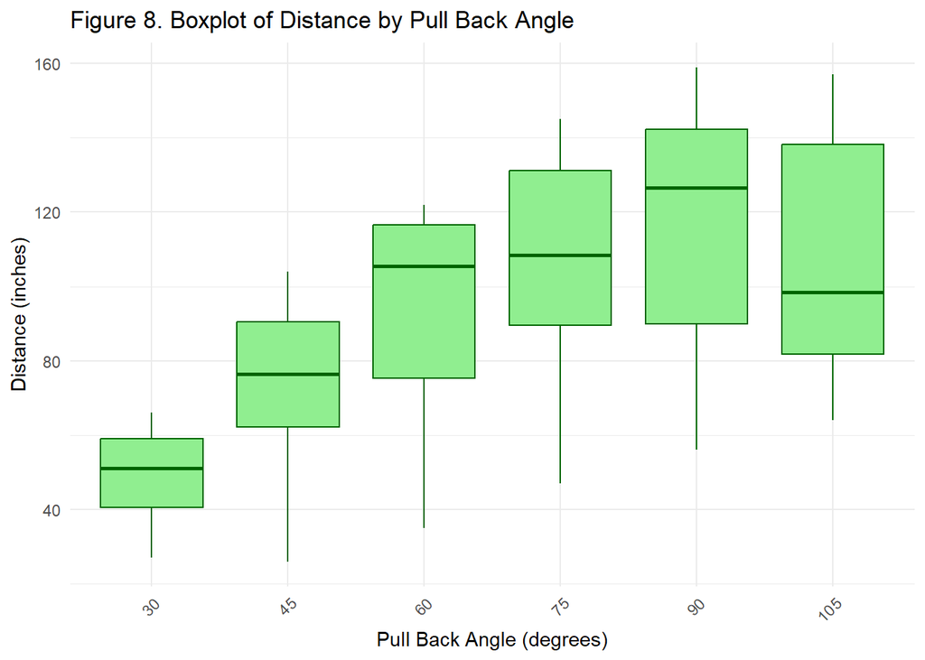

Table 4. Descriptive Summary of Distances

| PullBackAngleFactor | Min | Q1 | Median | Mean | Q3 | Max |
| --- | --- | --- | --- | --- | --- | --- |
| 30 | 27 | 40.50 | 51.0 | 48.96667 | 59.00 | 66 |
| 45 | 26 | 62.25 | 76.5 | 73.10000 | 90.50 | 104 |
| 60 | 35 | 75.25 | 105.5 | 94.90000 | 116.50 | 122 |
| 75 | 47 | 89.50 | 108.5 | 105.33333 | 131.25 | 145 |
| 90 | 56 | 90.00 | 126.5 | 116.63333 | 142.25 | 159 |
| 105 | 64 | 81.75 | 98.5 | 107.03333 | 138.25 | 157 |

# 4 Model Creation and Adequacy Check

As only two factors were intentionally adjusted (the pull-back angle and the launch angle), the data will be analyzed using a Two-Way Analysis of Variance (ANOVA) model.

The following is the generic equation for the model:

$y_{ijk} = \mu + \tau_{i} + \beta_{j} + (\tau\beta)_{ij} + \epsilon_{ijk}$

for i = Pull Back Angle = 30, 45, 60, 75, 90, and 105 degrees.

for j = Launch Angle = 0, 15, 30, 45, 60, and 75 degrees

Where y is the cell mean, $\mu$ is the Grand Mean, $\tau$ is the Row Effect = Pull Back Angle, $\beta$ is the Column Effect = Launch Angle, $\tau\beta$ is the interaction term, and $\epsilon$ is a random error component.

Below is the setup of the two-way ANOVA model, the summary of the model results, and an analysis of the residuals. A test for homogeneity of factor level variances is not applicable as the model created is a Two-Way ANOVA. The following hypotheses are what will be evaluated for the model:

*For the Residuals*

$H_0$: The residuals are normally distributed.

$H_1$: The residuals are not normally distributed.

*Factor = Pull Back Angle*

$H_0$: Pull Back Angle is not a significant treatment in influencing the distance traveled by the ping pong ball from the catapult (i.e., $\tau_30 = \tau_45 = \tau_60 = \tau_75 = \tau_90 = \tau_105 = 0$).

$H_1$: Pull Back Angle is a significant treatment in influencing the distance traveled by the ping pong ball from the catapult (i.e., at least one $\tau_i \neq 0$).

*Factor = Launch Angle*

$H_0$: Launch Angle is not a significant treatment in influencing the distance traveled by the ping pong ball from the catapult (i.e., $\beta_{0} = \beta_{15}=\beta_{30}=\beta_{45}=\beta_{60}=\beta_{75}=0$).

$H_1$: Launch Angle is a significant treatment in influencing the distance traveled by the ping pong ball from the catapult (i.e., at least one $\beta_i \neq 0$).

*Interaction between Pull Back Angle and Launch Angle*

$H_0$: The interaction term is not significant in influencing the distance traveled by the ping pong ball from the catapult ($\tau\beta_{ij} = 0$ for all i,j).

$H_1$: The interaction term is significant in influencing the distance traveled by the ping pong ball from the catapult (i.e., at least one $\tau\beta_{ij} \neq 0$).

**Figure 9**, **Figure 10**, and **Figure 11** are a boxplot, histogram, and QQ plot of the residuals of the two-way ANOVA model, respectively. These graphs show that the residuals appear to be normally distributed, but the Shapiro-Wilks test for normality and the Anderson-Darling test for normality were also completed. Those results and their conclusion are discussed below the following output.

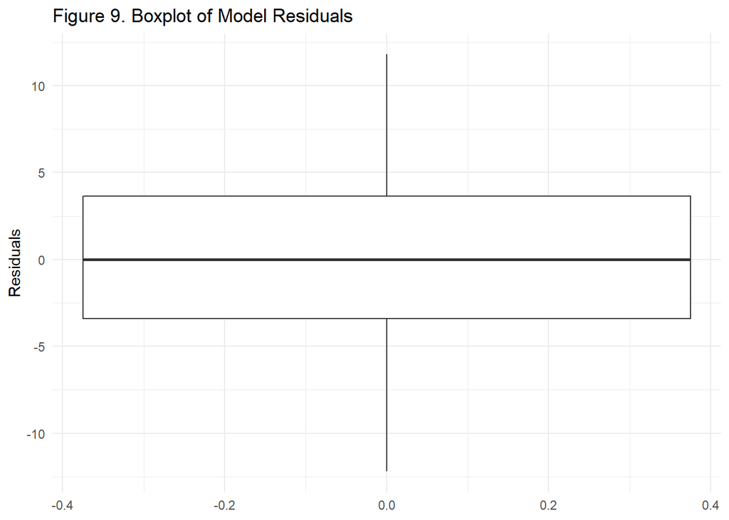

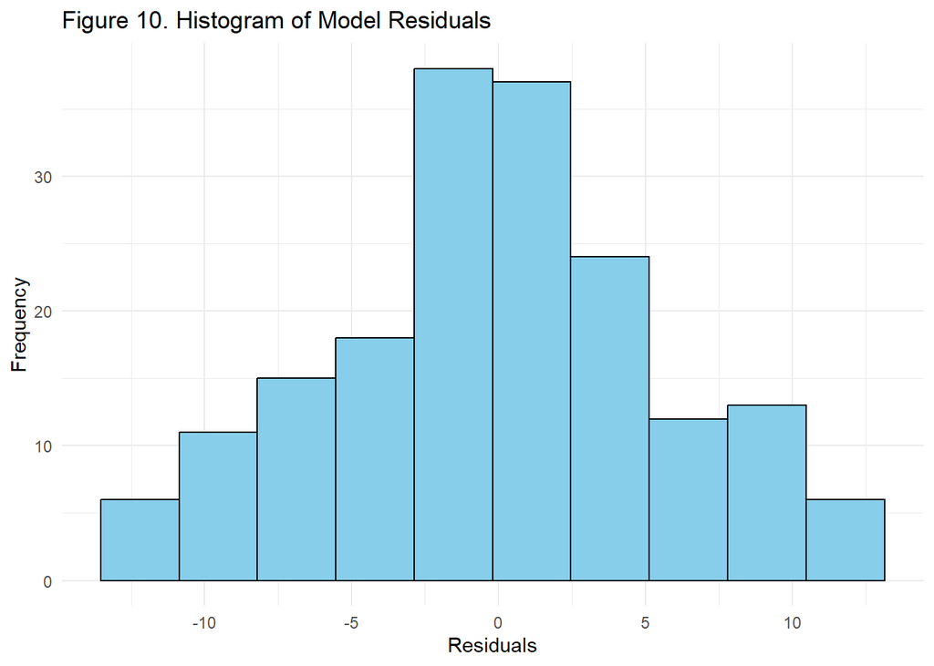

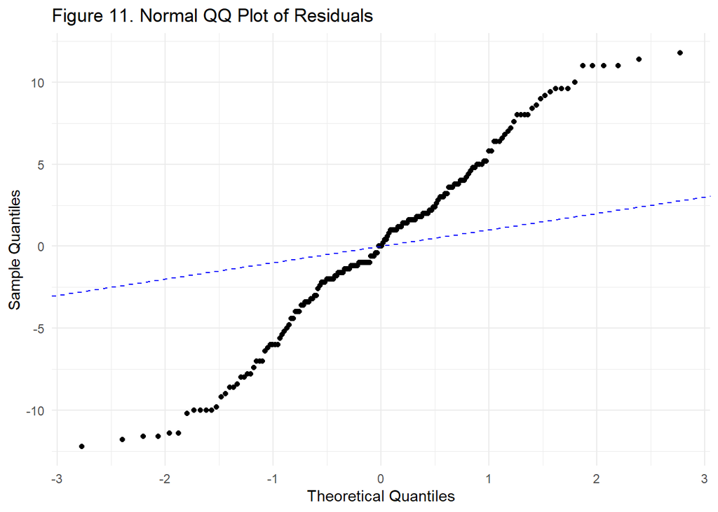

```
##
##  Shapiro-Wilk normality test
##
## data:  model1$residuals
## W = 0.98519, p-value = 0.05427
```

```
##
##  Anderson-Darling normality test
##
## data:  model1$residuals
## A = 0.52426, p-value = 0.1795
```

Assuming a 95% level of confidence ($\alpha = 0.05$), the resulting p-values from both the Shapiro-Wilk test (0.05427) and the Anderson-Darling Test (0.1795) are greater than $\alpha$=0.05; thus there is insufficient evidence to reject the null hypothesis. The residuals are normally distributed. This diagnostic is acceptable, so no action needs to be taken to create a valid/adequate model on the account of the residuals.

The output below contains the ANOVA table summary of the model as well as an interaction plot:

```
##                                        Df Sum Sq Mean Sq F value Pr(>F)
## LaunchAngleFactor                       5  82822   16564  424.76 <2e-16 ***
## PullBackAngleFactor                     5  96660   19332  495.73 <2e-16 ***
## LaunchAngleFactor:PullBackAngleFactor  25  34079    1363   34.96 <2e-16 ***
## Residuals                             144   5616      39
## ---
## Signif. codes:  0 '***' 0.001 '**' 0.01 '*' 0.05 '.' 0.1 ' ' 1
```

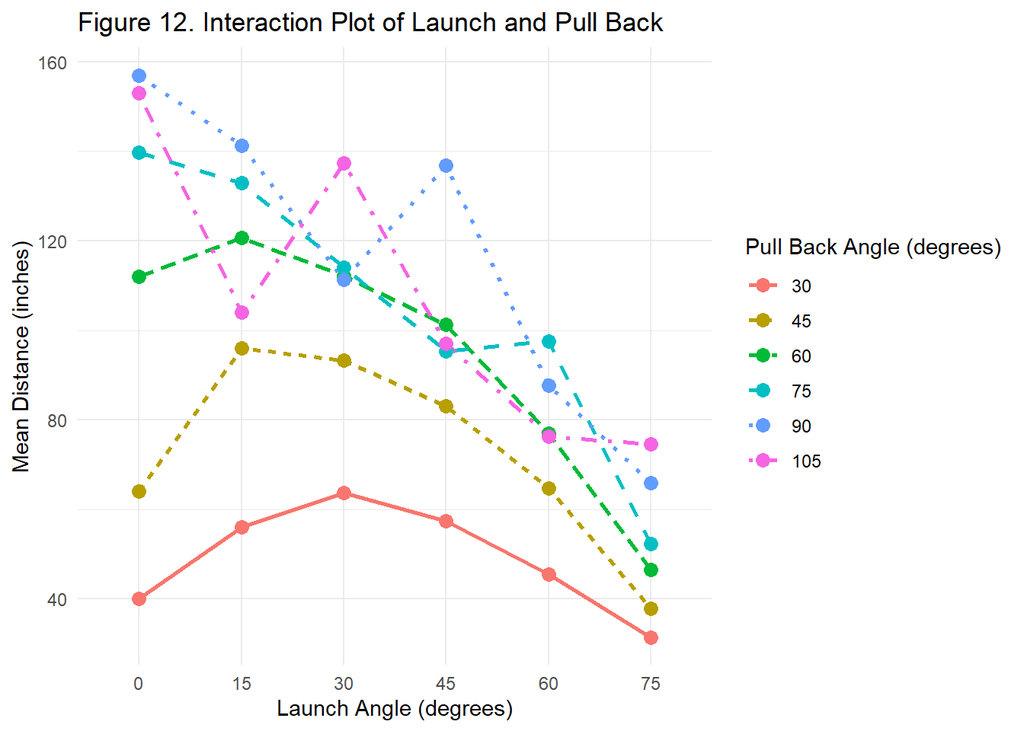

Assuming a 95% level of confidence ($\alpha = 0.05$), the resulting p-value for the launch angle factor (<2e-16), the pull back angle factor (<2e-16), and the interaction term (<2e-16) are less than $\alpha$=0.05; thus there is sufficient evidence to reject the null hypotheses that pertain the to two factors and the interaction term. The launch angle, pull back angle, and their interaction are significant in influencing the distance traveled by the ping pong ball from the catapult.

Additionally, the interaction plot (**Figure 12**) reveals that the slopes of the pull back angle are not parallel, thus supporting the finding that the interaction between the launch and pull back angle is significant.

As the interaction term has been shown to be significant, the effect of one of the independent variable (launch and pull back angle) does depend on the level of the other independent variable; therefore we will focus on the simple main effects (i.e., the different launch angles within the pull back angles and vice versa). The following output shows the result of the simple main effects comparison assessment and the findings are summarized on the subsequent pages:

```
##        Distance_inches groups
## 0.90             157.0      a
## 0.105            153.0     ab
## 15.90            141.2     bc
## 0.75             139.8     bc
## 30.105           137.4      c
## 45.90            136.8      c
## 15.75            133.0     cd
## 15.60            120.6     de
## 30.75            114.0     ef
## 30.60            112.2    efg
## 0.60             112.0    efg
## 30.90            111.4   efgh
## 15.105           104.0   fghi
## 45.60            101.2  fghij
## 60.75             97.6  ghijk
## 45.105            97.0  ghijk
## 15.45             96.0   hijk
## 45.75             95.4    ijk
## 30.45             93.2    ijk
## 60.90             87.6    jkl
## 45.45             83.0     kl
## 60.60             77.0     lm
## 60.105            76.2     lm
## 75.105            74.6     lm
## 75.90             65.8     mn
## 60.45             64.6     mn
## 0.45              64.0     mn
## 30.30             63.6     mn
## 45.30             57.4     no
## 15.30             56.0     no
## 75.75             52.2    nop
## 75.60             46.4    opq
## 60.30             45.4    opq
## 0.30              40.0     pq
## 75.45             37.8     pq
## 75.30             31.4      q
```

*For Launch Angle*

For Launch Angle = 0 (from lowest to highest mean distance),

Pull Back Angle 30 has unique letters “pq” and is the lowest

Pull Back Angles 45 and 60 are next with unique letters

Pull Back Angle 75 shares letter b with Pull Back Angle 105

Pull Back Angle 90 shares letter a with Pull Back Angle 105

For Launch Angle = 15 (from lowest to highest mean distance),

Pull Back Angle 30 has unique letters “no”

Pull Back Angle 45 and 105 shares letter “hi”

Pull Back Angles 75 and 90 share c

For Launch Angle = 30 (from lowest to highest mean distance),

Pull Back Angles 90 and 60 share “efg”

Pull Back Angles 60 and 75 share “ef”

Launch Angle = 30: $\mu_{PB=30}\mu_{PB=45}\mu_{PB=90}\mu_{PB=60}\mu_{PB=75}\mu_{PB=105}$

For Launch Angle = 45 (from lowest to highest mean distance),

Pull Back Angles 45, 75, and 105 share “k”

Pull Back Angles 75 and 105 share “ijk”

Pull Back Angles 75, 105, and 60 share “ij”

Pull Back Angles 105 and 60 share “ghij”

Launch Angle = 45: $\mu_{PB=30}\mu_{PB=45}\mu_{PB=75}\mu_{PB=105}\mu_{PB=60}\mu_{PB=90}$

For Launch Angle = 60 (from lowest to highest mean distance),

Pull Back Angles 45, 105, and 60 share “m”

Pull Back Angles 105 and 60 share “lm”

Pull Back Angles 60 and 90 share “l”

Pull Back Angles 90 and 75 share “jk”

Launch Angle = 60: $\mu_{PB=30}\mu_{PB=45}\mu_{PB=105}\mu_{PB=60}\mu_{PB=90}\mu_{PB=75}$

For Launch Angle = 75 (from lowest to highest mean distance),

Pull Back Angles 30, 45, and 60 share “q”

Pull Back Angles 45 and 60 share “pq”

Pull Back Angles 60 and 75 share “op”

Pull Back Angles 75 and 90 share “n”

Pull Back Angles 90 and 105 share “m”

Launch Angle = 75: $\mu_{PB=30}\mu_{PB=45}\mu_{PB=60}\mu_{PB=75}\mu_{PB=90}\mu_{PB=105}$

*For Pull Back Angle*

For Pull Back Angle = 30 (from lowest to highest mean distance),

Launch Angles 75, 0 and 60 share “q”

Launch Angles 0 and 60 share “pq”

Launch Angles 60, 15, and 45 share “o”

Launch Angles 15 and 45 share “no”

Launch Angles 45 and 30 share “n”

Pull Back Angle = 30: $\mu_{LA=75}\mu_{LA=0}\mu_{LA=60}\mu_{LA=15}\mu_{LA=45}\mu_{LA=30}$

For Pull Back Angle = 45 (from lowest to highest mean distance),

Launch Angle 75 does not share any letters

Launch Angles 0 and 60 share “mn”

Launch Angles 45, 30, and 15 share “k”

Launch Angles 30 and 15 share “jk”

Pull Back Angle = 45: $\mu_{LA=75}\mu_{LA=0}\mu_{LA=60}\mu_{LA=45}\mu_{LA=30}\mu_{LA=15}$

For Pull Back Angle = 60 (from lowest to highest mean distance),

Launch Angles 15, 0, and 30 share “e”

Launch Angle 75 does not share any letters

Launch Angle 60 does not share any letters

Launch Angles 45, 0, and 30 share “fg”

For Pull Back Angle = 75 (from lowest to highest mean distance),

Launch Angle 75 does not share any letters

Launch Angles 45 and 60 share “ijk”

Launch Angle 30 does not share any letters

Launch Angles 15 and 0 share “c”

Pull Back Angle = 75: $\mu_{LA=75}\mu_{LA=45}\mu_{LA=60}\mu_{LA=30}\mu_{LA=15}\mu_{LA=0}$

For Pull Back Angle = 90 (from lowest to highest mean distance),

Launch Angle 75 does not share any letters

Launch Angle 60 does not share any letters

Launch Angle 30 does not share any letters

Launch Angles 45 and 15 share “c”

Launch Angle 0 does not share any letters

Pull Back Angle = 90: $\mu_{LA=75}\mu_{LA=60}\mu_{LA=30}\mu_{LA=45}\mu_{LA=15}\mu_{LA=0}$

For Pull Back Angle = 105 (from lowest to highest mean distance),

Launch Angle 75 and 60 share “lm”

Launch Angles 45 and 15 share “ghi”

Launch Angle 30 does not share any letters

Launch Angle 0 does not share any letters

Pull Back Angle = 105: $\mu_{LA=75}\mu_{LA=60}\mu_{LA=45}\mu_{LA=15}\mu_{LA=30}\mu_{LA=0}$

# 5 Recommeded Settings for Maximum Distance and 11 ft Distance and Results

On December 8, 2023, Dr. Professor’s Experimental Design course met in room PE 137 to test the validity and accuracy of the models created by each student using the catapults and clamps provided for data collection. The same table for mounting the catapult during data collection was used (see **Figure 3**) and a standard 25-foot retractable tape measure was used. Each student used two rubber bands to stabilize the pull-back angle, a smooth ping pong ball, and their respective models they built with their data for two different tests.

**Table 5** shown below was used to quickly determine the appropriate pull back and launch angles to use for the tests. Only observations with fitted values greater than 120 inches are shown due to the tests being evaluated (i.e., maximum distance and accuracy at 11 ft).

Table 5. Observations Where Fitted Values Are Greater than 120 inches

|  | Distance_inches | PullBackAngleFactor | LaunchAngleFactor | FittedValues |
| --- | --- | --- | --- | --- |
| 21 | 155 | 90 | 0 | 157.0 |
| 25 | 159 | 90 | 0 | 157.0 |
| 22 | 156 | 90 | 0 | 157.0 |
| 23 | 156 | 90 | 0 | 157.0 |
| 24 | 159 | 90 | 0 | 157.0 |
| 27 | 153 | 105 | 0 | 153.0 |
| 29 | 156 | 105 | 0 | 153.0 |
| 26 | 145 | 105 | 0 | 153.0 |
| 30 | 157 | 105 | 0 | 153.0 |
| 28 | 154 | 105 | 0 | 153.0 |
| 54 | 145 | 90 | 15 | 141.2 |
| 55 | 146 | 90 | 15 | 141.2 |
| 51 | 132 | 90 | 15 | 141.2 |
| 52 | 140 | 90 | 15 | 141.2 |
| 53 | 143 | 90 | 15 | 141.2 |
| 17 | 135 | 75 | 0 | 139.8 |
| 18 | 143 | 75 | 0 | 139.8 |
| 19 | 144 | 75 | 0 | 139.8 |
| 20 | 145 | 75 | 0 | 139.8 |
| 16 | 132 | 75 | 0 | 139.8 |
| 86 | 126 | 105 | 30 | 137.4 |
| 87 | 136 | 105 | 30 | 137.4 |
| 88 | 139 | 105 | 30 | 137.4 |
| 89 | 142 | 105 | 30 | 137.4 |
| 90 | 144 | 105 | 30 | 137.4 |
| 111 | 135 | 90 | 45 | 136.8 |
| 112 | 135 | 90 | 45 | 136.8 |
| 113 | 137 | 90 | 45 | 136.8 |
| 114 | 138 | 90 | 45 | 136.8 |
| 115 | 139 | 90 | 45 | 136.8 |
| 46 | 129 | 75 | 15 | 133.0 |
| 47 | 129 | 75 | 15 | 133.0 |
| 48 | 132 | 75 | 15 | 133.0 |
| 49 | 137 | 75 | 15 | 133.0 |
| 50 | 138 | 75 | 15 | 133.0 |
| 41 | 117 | 60 | 15 | 120.6 |
| 42 | 120 | 60 | 15 | 120.6 |
| 43 | 122 | 60 | 15 | 120.6 |
| 44 | 122 | 60 | 15 | 120.6 |
| 45 | 122 | 60 | 15 | 120.6 |

According to the fitted values from the Two-Way Anova Model outlined earlier in this text, the settings for maximum distance would be a launch angle of 0 degrees and a pull back angle of 90 degrees (see **Table 5**). Of note, MeowmyofSix did use two new rubber bands from an XPULT Experimental Catapult kit purchased by her a couple of months prior to the experiment. It was noted that the new rubber bands “felt different” than the older, previously used rubber bands used for the data collection that were provided in the kit supplied by Dr. Professor. The three distances recorded from MeowmyofSix’s catapult by Dr. Professor were 273 inches, 262 inches, and 258 inches. Note that these distances were longer than any distances measured in the data found in the Appendix (the maximum distance from data collection was 159 inches). These distances ended up coming in second place out of six individuals completing the same test with their respective catapults and models.

# 6 Conclusion and Discussion

Although the Two-Way ANOVA model created was shown to be valid (and the factors and interaction term of pull back angle and launch angle for were shown to be significant), the model did not accurately predict the maximum distance nor accuracy of the ping pong ball being fired from the catapult using the data included in the **Appendix**.

It was very evident not only during the tests completed on December 8, 2023 but also during the data collection that there were other factors that were “controlled” as well as sources of error that likely impact the distance and accuracy of a ping pong ball’s distance when catapulted.

The use of two new “fresh” rubber bands as opposed to two “old” rubber bands heavily influenced the outcome of the experiment. Using new rubber bands heavily impacted the distance ping pong ball traveled per the optimized settings identified via the Two-Way ANOVA model. This lends to a third factor that could (and possibly should) have been established to set up a (possibly) better model via a Three Way ANOVA: number of rubber bands with perhaps some control on their age and/or number of uses.

There were also inconsistencies in the exact “manner” in which the catapult’s arm was pulled back. It was noticed that distance and quality of the ping pong ball’s firing seemed to vary by how someone pulled back the catapult’s arm (i.e., speed of setup/release, pressure, etc.). This would be much harder to control and would like involve using some device that would consistently apply a given pressure at a certain speed of release. It’s possible that the varying “manner” of pulling back and releasing the catapult’s arm likely caused some variation in the “actual” pull back angle used (i.e., if one was aiming for a pull back angle of 90, perhaps it was slightly more or less than 90 for each pull of the catapult arm.).

Another source of error in terms of “how” the catapult was fired was how “snug” the ping pong ball was placed into the ball cup. Sometimes the ball would become stuck in the ball cup and consequently the ball would be prevented from leaving the catapult or the flight of the ball would be heavily hindered.

Perhaps one of the larger sources of error introduced to the experiment was the method used for measuring where the ping pong ball landed once fired. A student would watch to see where the ball landed along a 1” wide tape measure and would call out the measurement to the person recording the results. Due to how quickly the experiment moved and also that the ping pong ball did not always land directly on the tape measure, it could become quite difficult for the person calling out the reading to accurately and precisely capture the actual distance result.

The experiment was also limited to one type of ball when another one was available (a light plastic ball with small holes). If we were to include this as a fourth factor (along with the third factor of the rubber band mentioned above), we would have to limit the settings of the pull back angle, launch angle, and number of rubber bands to two levels to permit the development of a 2^k factorial experimental design and model.

However, this project was effective in familiarizing the student with designing experiments from setting up the experiment and identifying the independent and dependent variables (and the levels of the independent variables), experiment execution and data collection (and its pitfalls), data cleaning, summarizing data, and choosing and validating an appropriate model based on the design of the experiment.

# 7 References

Peloton Systems, LLC, 2018. “XPULT INSTRUCTIONS - ADVANCED VERSION (11th Grade - College).” Accessed November 15, 2023. https://xpult.com/documents/xpult-instructions-advanced.pdf.

Peloton Systems, LLC, 2018. “ABOUT US.” Accessed November 15, 2023. https://xpult.com/xpult-catapult-about-us.html.

# 8 Appendix

Appendix - Data Collected 11/15/2023 and 11/21/2023

| Observation | LaunchAngle | PullBackAngle | Distance_inches | Day |
| --- | --- | --- | --- | --- |
| 1 | 0 | 30 | 34 | 2023-11-15 |
| 2 | 0 | 30 | 35 | 2023-11-15 |
| 3 | 0 | 30 | 38 | 2023-11-15 |
| 4 | 0 | 30 | 43 | 2023-11-15 |
| 5 | 0 | 30 | 50 | 2023-11-15 |
| 8 | 0 | 45 | 58 | 2023-11-15 |
| 9 | 0 | 45 | 61 | 2023-11-15 |
| 10 | 0 | 45 | 64 | 2023-11-15 |
| 6 | 0 | 45 | 65 | 2023-11-15 |
| 7 | 0 | 45 | 72 | 2023-11-15 |
| 11 | 0 | 60 | 102 | 2023-11-15 |
| 12 | 0 | 60 | 104 | 2023-11-15 |
| 13 | 0 | 60 | 117 | 2023-11-15 |
| 14 | 0 | 60 | 117 | 2023-11-15 |
| 15 | 0 | 60 | 120 | 2023-11-15 |
| 20 | 0 | 75 | 132 | 2023-11-15 |
| 17 | 0 | 75 | 135 | 2023-11-15 |
| 19 | 0 | 75 | 143 | 2023-11-15 |
| 16 | 0 | 75 | 144 | 2023-11-15 |
| 18 | 0 | 75 | 145 | 2023-11-15 |
| 23 | 0 | 90 | 155 | 2023-11-15 |
| 25 | 0 | 90 | 156 | 2023-11-15 |
| 22 | 0 | 90 | 156 | 2023-11-15 |
| 24 | 0 | 90 | 159 | 2023-11-15 |
| 21 | 0 | 90 | 159 | 2023-11-15 |
| 27 | 0 | 105 | 145 | 2023-11-15 |
| 30 | 0 | 105 | 153 | 2023-11-15 |
| 28 | 0 | 105 | 154 | 2023-11-15 |
| 26 | 0 | 105 | 156 | 2023-11-15 |
| 29 | 0 | 105 | 157 | 2023-11-15 |

[output cut: 150 more lines]